# Segmentación de Clientes de Tarjetas de Crédito

## Contexto de Negocio y Problema

Un banco colombiano tiene datos de consumo de más de 47,000 tarjetahabientes, pero no cuenta con una forma de agrupar a estos clientes según el uso que le dan a su tarjeta. Sin esta segmentación, las promociones se diseñan de forma genérica, sin aprovechar los patrones de consumo, gasto y comportamiento.

**Objetivo:** segmentar a los clientes usando clustering K-Means basado en su comportamiento transaccional, para habilitar estrategias promocionales más enfocadas y basadas en datos.

```python
import pandas as pd
from google.colab import drive
drive.mount('/content/drive')
df = pd.read_excel('/content/drive/MyDrive/Colab Notebooks/Portfolio/Python_SQL/infoclientebanca_en.xlsx')
df.head()
```

|  | CLIENT | client_group | number_of_transactions | avg_transaction_amount | min_transaction_amount | max_transaction_amount | transaction_std_dev | pct_visa_domestic | pct_visa_international | pct_mastercard_domestic | ... | pct_afternoon | pct_evening | pct_sunday | pct_monday | pct_tuesday | pct_wednesday | pct_thursday | pct_friday | pct_saturday | most_frequent_merchant_category |
| --- | --- | --- | --- | --- | --- | --- | --- | --- | --- | --- | --- | --- | --- | --- | --- | --- | --- | --- | --- | --- | --- |
| 0 | 1 | A | 1 | 459930.3 | 459930.3 | 459930.3 | 0.00 | 0.0 | 1.0 | 0.0 | ... | 0.0 | 1.0 | 0.0 | 0.000000 | 1.0 | 0.0 | 0.000000 | 0.0 | 0.0 | CLINICS - HOSPITALS |
| 1 | 2 | A | 3 | 582666.7 | 350000.0 | 699000.0 | 201495.23 | 1.0 | 0.0 | 0.0 | ... | 1.0 | 0.0 | 0.0 | 0.666667 | 0.0 | 0.0 | 0.333333 | 0.0 | 0.0 | DIRECT MARKETING - TELEMARKETING / DIRECTV |
| 2 | 3 | A | 3 | 616547.0 | 616547.0 | 616547.0 | 0.00 | 1.0 | 0.0 | 0.0 | ... | 0.0 | 0.0 | 0.0 | 0.000000 | 0.0 | 1.0 | 0.000000 | 0.0 | 0.0 | PHARMACIES, DRUGSTORES, HEALTH FOOD STORES |
| 3 | 4 | A | 10 | 144467.1 | 20000.0 | 328444.0 | 116685.81 | 0.0 | 0.0 | 1.0 | ... | 0.6 | 0.0 | 0.0 | 0.600000 | 0.2 | 0.0 | 0.100000 | 0.0 | 0.1 | DEPARTMENT STORE WITH SUPERMARKET |
| 4 | 5 | A | 1 | 321764.0 | 321764.0 | 321764.0 | 0.00 | 1.0 | 0.0 | 0.0 | ... | 1.0 | 0.0 | 1.0 | 0.000000 | 0.0 | 0.0 | 0.000000 | 0.0 | 0.0 | DEPARTMENT STORE WITH SUPERMARKET |

5 rows × 26 columns

```python
#Eliminar las variables que no se requieren para el clustering; most_frequent_merchant_category se transformará por separado.
df_1 = df.drop(['CLIENT','client_group','most_frequent_merchant_category'], axis=1)
df_1.head()
```

|  | number_of_transactions | avg_transaction_amount | min_transaction_amount | max_transaction_amount | transaction_std_dev | pct_visa_domestic | pct_visa_international | pct_mastercard_domestic | pct_mastercard_international | pct_other_card_domestic | ... | pct_morning | pct_afternoon | pct_evening | pct_sunday | pct_monday | pct_tuesday | pct_wednesday | pct_thursday | pct_friday | pct_saturday |
| --- | --- | --- | --- | --- | --- | --- | --- | --- | --- | --- | --- | --- | --- | --- | --- | --- | --- | --- | --- | --- | --- |
| 0 | 1 | 459930.3 | 459930.3 | 459930.3 | 0.00 | 0.0 | 1.0 | 0.0 | 0.0 | 0.0 | ... | 0.0 | 0.0 | 1.0 | 0.0 | 0.000000 | 1.0 | 0.0 | 0.000000 | 0.0 | 0.0 |
| 1 | 3 | 582666.7 | 350000.0 | 699000.0 | 201495.23 | 1.0 | 0.0 | 0.0 | 0.0 | 0.0 | ... | 0.0 | 1.0 | 0.0 | 0.0 | 0.666667 | 0.0 | 0.0 | 0.333333 | 0.0 | 0.0 |
| 2 | 3 | 616547.0 | 616547.0 | 616547.0 | 0.00 | 1.0 | 0.0 | 0.0 | 0.0 | 0.0 | ... | 1.0 | 0.0 | 0.0 | 0.0 | 0.000000 | 0.0 | 1.0 | 0.000000 | 0.0 | 0.0 |
| 3 | 10 | 144467.1 | 20000.0 | 328444.0 | 116685.81 | 0.0 | 0.0 | 1.0 | 0.0 | 0.0 | ... | 0.4 | 0.6 | 0.0 | 0.0 | 0.600000 | 0.2 | 0.0 | 0.100000 | 0.0 | 0.1 |
| 4 | 1 | 321764.0 | 321764.0 | 321764.0 | 0.00 | 1.0 | 0.0 | 0.0 | 0.0 | 0.0 | ... | 0.0 | 1.0 | 0.0 | 1.0 | 0.000000 | 0.0 | 0.0 | 0.000000 | 0.0 | 0.0 |

5 rows × 23 columns

```python
#Transformar 'most_frequent_merchant_category' de categórica a numérica usando variables dummy (se conserva como referencia; no se usa en las variables de clustering de abajo).
df_2 = pd.get_dummies(df['most_frequent_merchant_category']).astype(int)
df_2.head()
```

|  | ADVERTISING, MEDIA AND GRAPHIC ARTS SERVICES | AGRICULTURAL EQUIPMENT, SUPPLIES AND SERVICES STORES | AIRLINES | AMBULANCE SERVICES | APPLIANCE AND GAS APPLIANCE STORES | ART GALLERIES - FRAME SHOPS | AUTO PARTS AND ACCESSORIES | AUTO REPAIR, BODYWORK, PAINT AND TOWING SERVICES | AUTO SERVICE CENTERS AND TIRE SHOPS | AVIATION COMPANIES | ... | TICKET AGENCIES (Theater Productions) except movies | TOBACCO AND LIQUOR STORES | TRAVEL AGENCIES AND TOUR OPERATORS | UNNAMED | UTILITIES | VARIETY, HOUSEWARES AND GIFT STORES / GENERAL STORES | VEHICLE RENTAL COMPANIES | VETERINARY CLINICS AND SERVICES | VIDEO RENTAL STORES | WATCH, JEWELRY AND SILVERWARE STORES |
| --- | --- | --- | --- | --- | --- | --- | --- | --- | --- | --- | --- | --- | --- | --- | --- | --- | --- | --- | --- | --- | --- |
| 0 | 0 | 0 | 0 | 0 | 0 | 0 | 0 | 0 | 0 | 0 | ... | 0 | 0 | 0 | 0 | 0 | 0 | 0 | 0 | 0 | 0 |
| 1 | 0 | 0 | 0 | 0 | 0 | 0 | 0 | 0 | 0 | 0 | ... | 0 | 0 | 0 | 0 | 0 | 0 | 0 | 0 | 0 | 0 |
| 2 | 0 | 0 | 0 | 0 | 0 | 0 | 0 | 0 | 0 | 0 | ... | 0 | 0 | 0 | 0 | 0 | 0 | 0 | 0 | 0 | 0 |
| 3 | 0 | 0 | 0 | 0 | 0 | 0 | 0 | 0 | 0 | 0 | ... | 0 | 0 | 0 | 0 | 0 | 0 | 0 | 0 | 0 | 0 |
| 4 | 0 | 0 | 0 | 0 | 0 | 0 | 0 | 0 | 0 | 0 | ... | 0 | 0 | 0 | 0 | 0 | 0 | 0 | 0 | 0 | 0 |

5 rows × 109 columns

```python
#Combinar ambos dataframes. df_cluster conserva todas las variables de comportamiento y se usará más adelante para el perfilamiento de clusters.
df_cluster = pd.concat([df_1, df_2], axis=1)
df_cluster.head()
```

|  | number_of_transactions | avg_transaction_amount | min_transaction_amount | max_transaction_amount | transaction_std_dev | pct_visa_domestic | pct_visa_international | pct_mastercard_domestic | pct_mastercard_international | pct_other_card_domestic | ... | TICKET AGENCIES (Theater Productions) except movies | TOBACCO AND LIQUOR STORES | TRAVEL AGENCIES AND TOUR OPERATORS | UNNAMED | UTILITIES | VARIETY, HOUSEWARES AND GIFT STORES / GENERAL STORES | VEHICLE RENTAL COMPANIES | VETERINARY CLINICS AND SERVICES | VIDEO RENTAL STORES | WATCH, JEWELRY AND SILVERWARE STORES |
| --- | --- | --- | --- | --- | --- | --- | --- | --- | --- | --- | --- | --- | --- | --- | --- | --- | --- | --- | --- | --- | --- |
| 0 | 1 | 459930.3 | 459930.3 | 459930.3 | 0.00 | 0.0 | 1.0 | 0.0 | 0.0 | 0.0 | ... | 0 | 0 | 0 | 0 | 0 | 0 | 0 | 0 | 0 | 0 |
| 1 | 3 | 582666.7 | 350000.0 | 699000.0 | 201495.23 | 1.0 | 0.0 | 0.0 | 0.0 | 0.0 | ... | 0 | 0 | 0 | 0 | 0 | 0 | 0 | 0 | 0 | 0 |
| 2 | 3 | 616547.0 | 616547.0 | 616547.0 | 0.00 | 1.0 | 0.0 | 0.0 | 0.0 | 0.0 | ... | 0 | 0 | 0 | 0 | 0 | 0 | 0 | 0 | 0 | 0 |
| 3 | 10 | 144467.1 | 20000.0 | 328444.0 | 116685.81 | 0.0 | 0.0 | 1.0 | 0.0 | 0.0 | ... | 0 | 0 | 0 | 0 | 0 | 0 | 0 | 0 | 0 | 0 |
| 4 | 1 | 321764.0 | 321764.0 | 321764.0 | 0.00 | 1.0 | 0.0 | 0.0 | 0.0 | 0.0 | ... | 0 | 0 | 0 | 0 | 0 | 0 | 0 | 0 | 0 | 0 |

5 rows × 132 columns

```python
#Construir las variables de entrada para el clustering: tras varias pruebas, usar TODAS las variables juntas producía una curva de codo sin quiebre visible
#(demasiadas variables correlacionadas/redundantes aplanan la curva de inercia). Reducir a las 2 variables que mejor diferencian
#el comportamiento de consumo -- número de transacciones y monto promedio por transacción -- y aplicarles transformación logarítmica (ambas están muy
#sesgadas: la mayoría de clientes tiene pocas transacciones, un grupo pequeño tiene muchas) produce un codo mucho más claro.
import numpy as np
from sklearn.preprocessing import StandardScaler

cluster_vars = df_cluster[['number_of_transactions', 'avg_transaction_amount']].copy()
cluster_vars['number_of_transactions'] = np.log1p(cluster_vars['number_of_transactions'])
cluster_vars['avg_transaction_amount'] = np.log1p(cluster_vars['avg_transaction_amount'])

scaler = StandardScaler()
array_norm = scaler.fit_transform(cluster_vars)
```

### Método del Codo para determinar el número óptimo de clusters

```python
#Evaluar de 1 a 6 clusters.
from sklearn.cluster import KMeans
inercias = []
for k in range(1, 7):
  kmeans = KMeans(n_clusters=k, random_state=42, n_init=10)
  kmeans.fit(array_norm)
  inercias.append(kmeans.inertia_)
```

```python
#Librería de gráficas
import matplotlib.pyplot as plt
# Paleta de colores
color_principal = '#f4df52'
colores_clusters = ['#f4df52', '#6940c9', '#D9BC07', '#9b7cff']
```

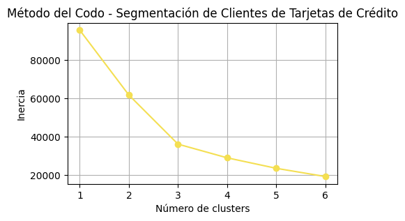

```python
#Graficar la inercia para identificar el número óptimo de clusters.
plt.figure(figsize=(5, 3))
plt.plot(range(1, 7), inercias, marker='o', color=color_principal)
plt.xlabel('Número de clusters')
plt.ylabel('Inercia')
plt.title('Método del Codo - Segmentación de Clientes de Tarjetas de Crédito')
plt.grid(True)
plt.show()
```

**Conclusión:** se eligen 3 clusters como el número óptimo, ya que la reducción de inercia se vuelve mucho menos significativa a partir de este punto, y 3 clusters ofrecen una segmentación clara y manejable de los clientes según frecuencia de transacción y nivel de gasto.

```python
#Entrenar el modelo final con 3 clusters.
Kmeans_final = KMeans(n_clusters=3, random_state=42, n_init=10)
Kmeans_final.fit(array_norm)
```

```
KMeans(n_clusters=3, n_init=10, random_state=42)
```

```python
#Agregar una columna que indica a qué cluster pertenece cada cliente.
df_cluster['cluster'] = Kmeans_final.labels_
df_cluster.head()
```

|  | number_of_transactions | avg_transaction_amount | min_transaction_amount | max_transaction_amount | transaction_std_dev | pct_visa_domestic | pct_visa_international | pct_mastercard_domestic | pct_mastercard_international | pct_other_card_domestic | ... | TOBACCO AND LIQUOR STORES | TRAVEL AGENCIES AND TOUR OPERATORS | UNNAMED | UTILITIES | VARIETY, HOUSEWARES AND GIFT STORES / GENERAL STORES | VEHICLE RENTAL COMPANIES | VETERINARY CLINICS AND SERVICES | VIDEO RENTAL STORES | WATCH, JEWELRY AND SILVERWARE STORES | cluster |
| --- | --- | --- | --- | --- | --- | --- | --- | --- | --- | --- | --- | --- | --- | --- | --- | --- | --- | --- | --- | --- | --- |
| 0 | 1 | 459930.3 | 459930.3 | 459930.3 | 0.00 | 0.0 | 1.0 | 0.0 | 0.0 | 0.0 | ... | 0 | 0 | 0 | 0 | 0 | 0 | 0 | 0 | 0 | 1 |
| 1 | 3 | 582666.7 | 350000.0 | 699000.0 | 201495.23 | 1.0 | 0.0 | 0.0 | 0.0 | 0.0 | ... | 0 | 0 | 0 | 0 | 0 | 0 | 0 | 0 | 0 | 1 |
| 2 | 3 | 616547.0 | 616547.0 | 616547.0 | 0.00 | 1.0 | 0.0 | 0.0 | 0.0 | 0.0 | ... | 0 | 0 | 0 | 0 | 0 | 0 | 0 | 0 | 0 | 1 |
| 3 | 10 | 144467.1 | 20000.0 | 328444.0 | 116685.81 | 0.0 | 0.0 | 1.0 | 0.0 | 0.0 | ... | 0 | 0 | 0 | 0 | 0 | 0 | 0 | 0 | 0 | 2 |
| 4 | 1 | 321764.0 | 321764.0 | 321764.0 | 0.00 | 1.0 | 0.0 | 0.0 | 0.0 | 0.0 | ... | 0 | 0 | 0 | 0 | 0 | 0 | 0 | 0 | 0 | 1 |

5 rows × 133 columns

```python
#Calcular el promedio de cada variable por cluster.
df_cluster.groupby('cluster').mean(numeric_only=True).round(2)
```

| cluster | number_of_transactions | avg_transaction_amount | min_transaction_amount | max_transaction_amount | transaction_std_dev | pct_visa_domestic | pct_visa_international | pct_mastercard_domestic | pct_mastercard_international | pct_other_card_domestic | ... | TICKET AGENCIES (Theater Productions) except movies | TOBACCO AND LIQUOR STORES | TRAVEL AGENCIES AND TOUR OPERATORS | UNNAMED | UTILITIES | VARIETY, HOUSEWARES AND GIFT STORES / GENERAL STORES | VEHICLE RENTAL COMPANIES | VETERINARY CLINICS AND SERVICES | VIDEO RENTAL STORES | WATCH, JEWELRY AND SILVERWARE STORES |
| --- | --- | --- | --- | --- | --- | --- | --- | --- | --- | --- | --- | --- | --- | --- | --- | --- | --- | --- | --- | --- | --- |
| 0 | 2.04 | 98579.66 | 76835.14 | 124724.74 | 26768.99 | 0.39 | 0.02 | 0.57 | 0.01 | 0.01 | ... | 0.0 | 0.0 | 0.00 | 0.07 | 0.0 | 0.02 | 0.0 | 0.0 | 0.0 | 0.0 |
| 1 | 2.23 | 846525.51 | 634758.75 | 1126643.43 | 252983.19 | 0.40 | 0.05 | 0.49 | 0.04 | 0.01 | ... | 0.0 | 0.0 | 0.03 | 0.11 | 0.0 | 0.01 | 0.0 | 0.0 | 0.0 | 0.0 |
| 2 | 14.32 | 204891.79 | 43151.95 | 639336.34 | 184833.86 | 0.32 | 0.05 | 0.57 | 0.04 | 0.02 | ... | 0.0 | 0.0 | 0.01 | 0.01 | 0.0 | 0.02 | 0.0 | 0.0 | 0.0 | 0.0 |

3 rows × 132 columns

### Parte 2: Análisis de Clusters Usando SQL

```python
#Crear otro dataframe donde 'most_frequent_merchant_category' no ha sido transformada ni eliminada.
#Eliminar las columnas que no se necesitan: 'CLIENT' y 'client_group'.
df_3 = df.drop(['CLIENT','client_group'], axis=1)
df_3.head()
```

|  | number_of_transactions | avg_transaction_amount | min_transaction_amount | max_transaction_amount | transaction_std_dev | pct_visa_domestic | pct_visa_international | pct_mastercard_domestic | pct_mastercard_international | pct_other_card_domestic | ... | pct_afternoon | pct_evening | pct_sunday | pct_monday | pct_tuesday | pct_wednesday | pct_thursday | pct_friday | pct_saturday | most_frequent_merchant_category |
| --- | --- | --- | --- | --- | --- | --- | --- | --- | --- | --- | --- | --- | --- | --- | --- | --- | --- | --- | --- | --- | --- |
| 0 | 1 | 459930.3 | 459930.3 | 459930.3 | 0.00 | 0.0 | 1.0 | 0.0 | 0.0 | 0.0 | ... | 0.0 | 1.0 | 0.0 | 0.000000 | 1.0 | 0.0 | 0.000000 | 0.0 | 0.0 | CLINICS - HOSPITALS |
| 1 | 3 | 582666.7 | 350000.0 | 699000.0 | 201495.23 | 1.0 | 0.0 | 0.0 | 0.0 | 0.0 | ... | 1.0 | 0.0 | 0.0 | 0.666667 | 0.0 | 0.0 | 0.333333 | 0.0 | 0.0 | DIRECT MARKETING - TELEMARKETING / DIRECTV |
| 2 | 3 | 616547.0 | 616547.0 | 616547.0 | 0.00 | 1.0 | 0.0 | 0.0 | 0.0 | 0.0 | ... | 0.0 | 0.0 | 0.0 | 0.000000 | 0.0 | 1.0 | 0.000000 | 0.0 | 0.0 | PHARMACIES, DRUGSTORES, HEALTH FOOD STORES |
| 3 | 10 | 144467.1 | 20000.0 | 328444.0 | 116685.81 | 0.0 | 0.0 | 1.0 | 0.0 | 0.0 | ... | 0.6 | 0.0 | 0.0 | 0.600000 | 0.2 | 0.0 | 0.100000 | 0.0 | 0.1 | DEPARTMENT STORE WITH SUPERMARKET |
| 4 | 1 | 321764.0 | 321764.0 | 321764.0 | 0.00 | 1.0 | 0.0 | 0.0 | 0.0 | 0.0 | ... | 1.0 | 0.0 | 1.0 | 0.000000 | 0.0 | 0.0 | 0.000000 | 0.0 | 0.0 | DEPARTMENT STORE WITH SUPERMARKET |

5 rows × 24 columns

```python
#Agregar una columna que indica a qué cluster pertenece cada cliente.
df_3['cluster'] = Kmeans_final.labels_
df_3.head()
```

|  | number_of_transactions | avg_transaction_amount | min_transaction_amount | max_transaction_amount | transaction_std_dev | pct_visa_domestic | pct_visa_international | pct_mastercard_domestic | pct_mastercard_international | pct_other_card_domestic | ... | pct_evening | pct_sunday | pct_monday | pct_tuesday | pct_wednesday | pct_thursday | pct_friday | pct_saturday | most_frequent_merchant_category | cluster |
| --- | --- | --- | --- | --- | --- | --- | --- | --- | --- | --- | --- | --- | --- | --- | --- | --- | --- | --- | --- | --- | --- |
| 0 | 1 | 459930.3 | 459930.3 | 459930.3 | 0.00 | 0.0 | 1.0 | 0.0 | 0.0 | 0.0 | ... | 1.0 | 0.0 | 0.000000 | 1.0 | 0.0 | 0.000000 | 0.0 | 0.0 | CLINICS - HOSPITALS | 1 |
| 1 | 3 | 582666.7 | 350000.0 | 699000.0 | 201495.23 | 1.0 | 0.0 | 0.0 | 0.0 | 0.0 | ... | 0.0 | 0.0 | 0.666667 | 0.0 | 0.0 | 0.333333 | 0.0 | 0.0 | DIRECT MARKETING - TELEMARKETING / DIRECTV | 1 |
| 2 | 3 | 616547.0 | 616547.0 | 616547.0 | 0.00 | 1.0 | 0.0 | 0.0 | 0.0 | 0.0 | ... | 0.0 | 0.0 | 0.000000 | 0.0 | 1.0 | 0.000000 | 0.0 | 0.0 | PHARMACIES, DRUGSTORES, HEALTH FOOD STORES | 1 |
| 3 | 10 | 144467.1 | 20000.0 | 328444.0 | 116685.81 | 0.0 | 0.0 | 1.0 | 0.0 | 0.0 | ... | 0.0 | 0.0 | 0.600000 | 0.2 | 0.0 | 0.100000 | 0.0 | 0.1 | DEPARTMENT STORE WITH SUPERMARKET | 2 |
| 4 | 1 | 321764.0 | 321764.0 | 321764.0 | 0.00 | 1.0 | 0.0 | 0.0 | 0.0 | 0.0 | ... | 0.0 | 1.0 | 0.000000 | 0.0 | 0.0 | 0.000000 | 0.0 | 0.0 | DEPARTMENT STORE WITH SUPERMARKET | 1 |

5 rows × 25 columns

```python
#Crear la base de datos SQLite y almacenar los datos de los clientes.
import sqlite3

conn = sqlite3.connect('banco.db')
df_3.to_sql('clientes', conn, if_exists='replace', index=False)
```

```
47871
```

```python
#Consulta 1: identificar la most_frequent_merchant_category de cada cluster y el número de clientes en ese grupo.
query = """
SELECT cluster, most_frequent_merchant_category, total
FROM (
    SELECT cluster, most_frequent_merchant_category, COUNT(*) as total,
           ROW_NUMBER() OVER (PARTITION BY cluster ORDER BY COUNT(*) DESC) as rn
    FROM clientes
    GROUP BY cluster, most_frequent_merchant_category
)
WHERE rn = 1
"""
#Crear el dataframe 'resultado' para almacenar los resultados de la consulta.
resultado = pd.read_sql_query(query, conn)
resultado.head()
```

|  | cluster | most_frequent_merchant_category | total |
| --- | --- | --- | --- |
| 0 | 0 | SUPERMARKETS / EXPRESS STORES | 4088 |
| 1 | 1 | SUPERMARKETS / EXPRESS STORES | 2220 |
| 2 | 2 | SUPERMARKETS / EXPRESS STORES | 2896 |

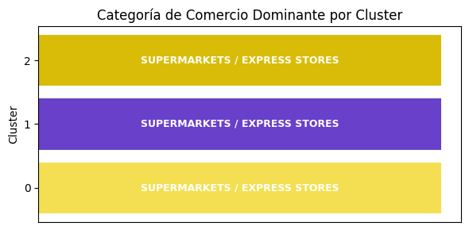

```python
plt.figure(figsize=(6, 3))
plt.barh(resultado['cluster'].astype(str), [1]*len(resultado), color=colores_clusters)
plt.ylabel('Cluster')
plt.xticks([])
plt.title('Categoría de Comercio Dominante por Cluster')

for i, sitio in enumerate(resultado['most_frequent_merchant_category']):
    plt.text(0.5, i, sitio, ha='center', va='center', color='white',
              fontweight='bold', fontsize=9)

plt.tight_layout()
plt.show()
```

```python
#Consulta 2: calcular el número de clientes y su participación dentro de cada cluster.
query = """
SELECT cluster, COUNT(cluster) as num_clientes,
ROUND((COUNT(cluster)*100.0/(SELECT COUNT(cluster) FROM clientes)),2) as porcentaje
FROM clientes
GROUP BY cluster
"""
resultado2 = pd.read_sql_query(query, conn)
resultado2['porcentaje'] = resultado2['porcentaje'].astype(str) + '%'
resultado2.head()
```

|  | cluster | num_clientes | porcentaje |
| --- | --- | --- | --- |
| 0 | 0 | 20436 | 42.69% |
| 1 | 1 | 15824 | 33.06% |
| 2 | 2 | 11611 | 24.25% |

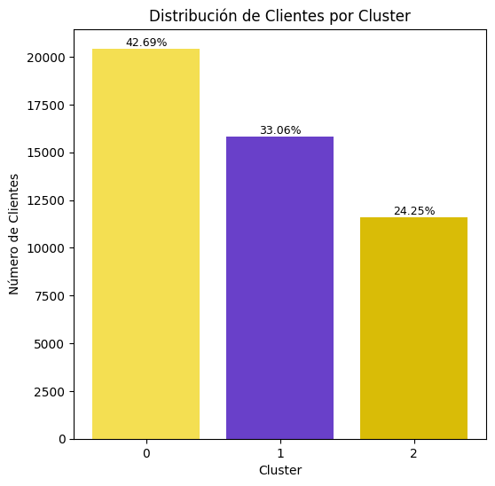

```python
plt.figure(figsize=(6, 6))
barras = plt.bar(
    resultado2['cluster'].astype(str),
    resultado2['num_clientes'],
    color=colores_clusters,
)
plt.xlabel('Cluster')
plt.ylabel('Número de Clientes')
plt.title('Distribución de Clientes por Cluster')
plt.grid(False)
for barra, porcentaje in zip(barras, resultado2['porcentaje']):
  plt.text(
      barra.get_x() + barra.get_width() / 2,
      barra.get_height(),
      porcentaje,
      ha='center',
      va='bottom',
      fontsize=9,
  )
plt.show()
```

**Conclusión:** los 3 clusters están bien balanceados, cada uno representa un perfil de comportamiento de consumo distinto basado en la frecuencia de transacciones y el tamaño promedio de la transacción.

```python
#Calcular el monto promedio por transacción para cada cluster.
promedio_transaccion = df_cluster.groupby('cluster')['avg_transaction_amount'].mean()
promedio_transaccion
```

| cluster | avg_transaction_amount |
| --- | --- |
| 0 | 98579.663110 |
| 1 | 846525.510553 |
| 2 | 204891.792495 |

**dtype:** float64

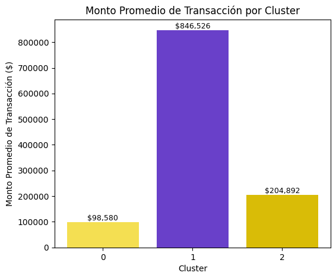

```python
plt.figure(figsize=(6, 5))
barras = plt.bar(promedio_transaccion.index.astype(str), promedio_transaccion.values, color=colores_clusters)
plt.xlabel('Cluster')
plt.ylabel('Monto Promedio de Transacción ($)')
plt.title('Monto Promedio de Transacción por Cluster')
plt.grid(False)

for barra, valor in zip(barras, promedio_transaccion.values):
    plt.text(barra.get_x() + barra.get_width()/2, barra.get_height(),
              f'${valor:,.0f}', ha='center', va='bottom', fontsize=9)
plt.show()
```

```python
#Consulta 3: participación promedio de transacciones realizadas con cada franquicia de tarjeta (Visa, Mastercard, otra) por cluster.
query = """
SELECT cluster,
AVG(pct_visa_domestic + pct_visa_international) as promedio_visa,
AVG(pct_mastercard_domestic + pct_mastercard_international) as promedio_mastercard,
AVG(pct_other_card_domestic + pct_other_card_international) as promedio_otrafranquicia
FROM clientes
GROUP BY cluster
"""
resultado3 = pd.read_sql_query(query, conn)
resultado3.head()
```

|  | cluster | promedio_visa | promedio_mastercard | promedio_otrafranquicia |
| --- | --- | --- | --- | --- |
| 0 | 0 | 0.406616 | 0.576361 | 0.017023 |
| 1 | 1 | 0.449276 | 0.524216 | 0.026508 |
| 2 | 2 | 0.367931 | 0.604177 | 0.027893 |

```python
#Identificar la franquicia más usada por cluster.
resultado3['tarjeta_mas_usada'] = resultado3[['promedio_visa', 'promedio_mastercard', 'promedio_otrafranquicia']].idxmax(axis=1)
resultado3['promedio_maximo'] = resultado3[['promedio_visa', 'promedio_mastercard', 'promedio_otrafranquicia']].max(axis=1)
resultado3_final = resultado3[['cluster', 'tarjeta_mas_usada', 'promedio_maximo']].merge(
    resultado2[['cluster', 'num_clientes']], on='cluster', how='left'
)
resultado3_final.head()
```

|  | cluster | tarjeta_mas_usada | promedio_maximo | num_clientes |
| --- | --- | --- | --- | --- |
| 0 | 0 | promedio_mastercard | 0.576361 | 20436 |
| 1 | 1 | promedio_mastercard | 0.524216 | 15824 |
| 2 | 2 | promedio_mastercard | 0.604177 | 11611 |

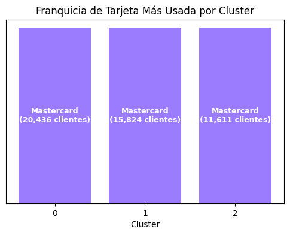

```python
plt.figure(figsize=(6, 4))
colores_franquicia = ['#9b7cff', '#9b7cff', '#9b7cff', '#f4df52']
plt.bar(resultado3_final['cluster'].astype(str), [1]*len(resultado3_final), color=colores_franquicia[:len(resultado3_final)])
plt.xlabel('Cluster')
plt.yticks([])
plt.title('Franquicia de Tarjeta Más Usada por Cluster')

for i, (tarjeta, n_clientes) in enumerate(zip(resultado3_final['tarjeta_mas_usada'], resultado3_final['num_clientes'])):
    label = tarjeta.replace('promedio_', '').capitalize()
    plt.text(i, 0.5, f'{label}\n({n_clientes:,} clientes)',
             ha='center', va='center', color='white', fontweight='bold', fontsize=9)
plt.show()
```

```python
#Calcular la participación promedio de gasto nacional vs. internacional por cluster.
nacional_internacional = df_cluster.groupby('cluster')[['pct_domestic_total', 'pct_international_total']].mean()
nacional_internacional
```

| cluster | pct_domestic_total | pct_international_total |
| --- | --- | --- |
| 0 | 0.969456 | 0.030544 |
| 1 | 0.896517 | 0.103483 |
| 2 | 0.898277 | 0.101723 |

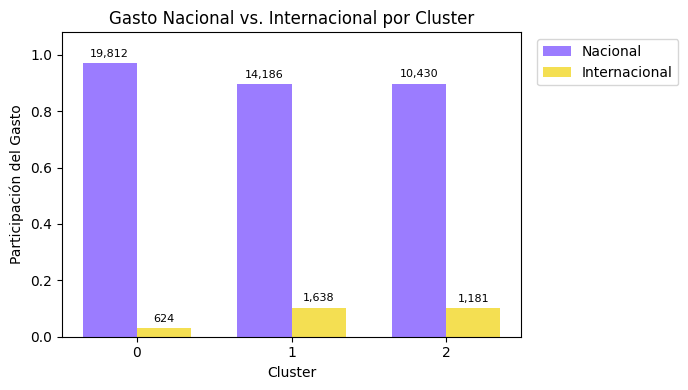

```python
import numpy as np
clusters = nacional_internacional.index.astype(str)
nac = nacional_internacional['pct_domestic_total']
inter = nacional_internacional['pct_international_total']
n_clientes_por_cluster = resultado2.set_index('cluster')['num_clientes']
x = np.arange(len(clusters))
width = 0.35
fig, ax = plt.subplots(figsize=(7, 4))
rects1 = ax.bar(x - width/2, nac, width, label='Nacional', color='#9b7cff')
rects2 = ax.bar(x + width/2, inter, width, label='Internacional', color='#f4df52')
for i, c in enumerate(nacional_internacional.index):
    n_cluster = n_clientes_por_cluster.loc[c]
    n_nac = round(n_cluster * nac.loc[c])
    n_inter = round(n_cluster * inter.loc[c])
    ax.text(x[i] - width/2, nac.loc[c] + 0.015, f'{n_nac:,}', ha='center', va='bottom', fontsize=8)
    ax.text(x[i] + width/2, inter.loc[c] + 0.015, f'{n_inter:,}', ha='center', va='bottom', fontsize=8)

ax.set_xlabel('Cluster')
ax.set_ylabel('Participación del Gasto')
ax.set_title('Gasto Nacional vs. Internacional por Cluster')
ax.set_xticks(x)
ax.set_xticklabels(clusters)
ax.set_ylim(0, 1.08)
ax.legend(bbox_to_anchor=(1.02, 1), loc='upper left')
plt.tight_layout()
plt.show()
```

```python
#Calcular la participación promedio de gasto en distintos momentos del día por cluster.
horario = df_cluster.groupby('cluster')[['pct_morning', 'pct_afternoon', 'pct_evening']].mean()
```

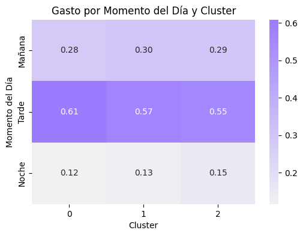

```python
import seaborn as sns
horario_display = horario.rename(columns={'pct_morning': 'Mañana', 'pct_afternoon': 'Tarde', 'pct_evening': 'Noche'})
cmap_morado = sns.light_palette("#9b7cff", as_cmap=True)
plt.figure(figsize=(6, 4))
sns.heatmap(horario_display.T, annot=True, fmt='.2f', cmap=cmap_morado)
plt.xlabel('Cluster')
plt.ylabel('Momento del Día')
plt.title('Gasto por Momento del Día y Cluster')
plt.show()
```

**Observación:** la tarde es el horario dominante en los tres clusters (55-61% del gasto), seguido por las mañanas (~28-30%) y las noches (12-15%). El patrón es consistente entre clusters, lo que significa que el momento del día no diferencia fuertemente a estos segmentos de clientes.

```python
#Calcular la participación promedio de gasto por día de la semana en cada cluster.
dias_semana = df_cluster.groupby('cluster')[['pct_sunday', 'pct_monday', 'pct_tuesday', 'pct_wednesday',
                                                'pct_thursday', 'pct_friday', 'pct_saturday']].mean()
```

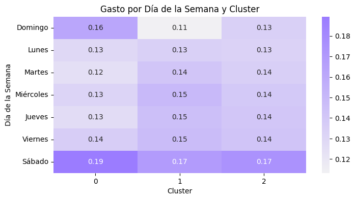

```python
dias_semana_display = dias_semana.rename(columns={
    'pct_sunday': 'Domingo', 'pct_monday': 'Lunes', 'pct_tuesday': 'Martes',
    'pct_wednesday': 'Miércoles', 'pct_thursday': 'Jueves', 'pct_friday': 'Viernes', 'pct_saturday': 'Sábado'
})

cmap_morado = sns.light_palette("#9b7cff", as_cmap=True)
plt.figure(figsize=(8, 4))
sns.heatmap(dias_semana_display.T, annot=True, fmt='.2f', cmap=cmap_morado)
plt.xlabel('Cluster')
plt.ylabel('Día de la Semana')
plt.title('Gasto por Día de la Semana y Cluster')
plt.show()
```

**Observación:** el sábado es el día de mayor gasto en los tres clusters (17-19% del gasto semanal), mientras que el resto de la semana muestra una distribución bastante uniforme. Al igual que con el momento del día, el patrón semanal es similar entre clusters y no distingue por sí solo a un segmento de otro.

## Análisis Final

> **El Cluster 0** es el grupo más grande, con **42.7% de los clientes** (20,436 clientes). Se caracteriza por baja frecuencia de transacciones (alrededor de 2 transacciones) y el monto promedio de transacción más bajo ($98,580), lo que lo convierte en el segmento "ocasional, de bajo gasto" del banco. Mastercard es la tarjeta preferida (57.6% del gasto) para compras nacionales (96.9% del gasto se queda a nivel nacional, la participación más alta de los tres clusters), y "Supermercados / Tiendas de Conveniencia" es la categoría de comercio dominante.

> **El Cluster 1** representa **33.1% de los clientes** (15,824 clientes). Al igual que el Cluster 0, estos clientes transaccionan con poca frecuencia (alrededor de 2 transacciones), pero su monto promedio por transacción es por mucho el más alto de los tres clusters, con **$846,526** — casi 9 veces más alto que el Cluster 0. Este es el segmento "ocasional, de alto valor" del banco: clientes que hacen compras grandes cuando sí usan la tarjeta. Mastercard vuelve a ser la franquicia líder (52.4%), y este cluster tiene la participación más alta de gasto internacional (10.3%) entre los tres.

> **El Cluster 2** es el grupo más pequeño con **24.2% de los clientes** (11,611 clientes), pero se destaca por su frecuencia de transacciones: estos clientes promedian **14.3 transacciones**, aproximadamente 6-7 veces más que los otros dos clusters, con un monto promedio de transacción intermedio ($204,892). Este es el segmento de "usuarios frecuentes" del banco. Mastercard sigue siendo dominante (60.4% del gasto), y el gasto internacional (10.2%) está cerca del nivel del Cluster 1.

## Recomendaciones de Negocio

> Dado que los tres clusters difieren principalmente en **frecuencia de transacción y gasto por transacción**, las promociones deberían adaptarse a cada comportamiento en lugar de aplicarse de forma uniforme:

> **Cluster 0 (ocasional, bajo gasto, 42.7% de los clientes):** la prioridad es aumentar el uso. Una promoción de cashback o puntos vinculada a Mastercard en compras de "Supermercados / Tiendas de Conveniencia" — su categoría dominante — podría fomentar un uso más frecuente de la tarjeta en un segmento que actualmente transacciona muy poco.

> **Cluster 1 (ocasional, alto valor, 33.1% de los clientes):** dado que estos clientes ya gastan montos altos por transacción, la oportunidad está en retención y en aumentar su participación de gasto (share-of-wallet), más que en frecuencia. Un programa de beneficios premium (seguro de viaje, acceso a salas VIP en aeropuertos, o protección de compras vinculada a Mastercard) encajaría con su perfil y con la participación de gasto internacional ligeramente más alta (10.3%) observada en este grupo.

> **Cluster 2 (usuarios frecuentes, 24.2% de los clientes):** este grupo ya transacciona con frecuencia, por lo que el objetivo es profundizar su lealtad. Un programa de recompensas escalonado que aumente los beneficios según el volumen de transacciones reforzaría su comportamiento actual y podría ayudar a migrar clientes del Cluster 0 hacia este perfil más activo con el tiempo.

> Como siguiente paso, dado que los patrones de categoría de comercio y horario son similares entre todos los clusters, un análisis más profundo de qué compran estos clientes dentro de "Supermercados / Tiendas de Conveniencia" y otras categorías frecuentes ayudaría a diseñar promociones más específicas a nivel de producto.

```python
!jupyter nbconvert --to html "/content/drive/MyDrive/Colab Notebooks/Portfolio/Python_SQL/ConsumoTarjetasCredito_ES.ipynb" --output-dir="/content/drive/MyDrive/Colab Notebooks/Portfolio/Python_SQL"
```

```
[NbConvertApp] Converting notebook /content/drive/MyDrive/Colab Notebooks/Portfolio/Python_SQL/ConsumoTarjetasCredito_ES.ipynb to html
[NbConvertApp] WARNING | Alternative text is missing on 8 image(s).
[NbConvertApp] Writing 708850 bytes to /content/drive/MyDrive/Colab Notebooks/Portfolio/Python_SQL/ConsumoTarjetasCredito_ES.html
```